# When Correlation Means Causation

Pragmatic factors modulate causal implicatures in decision-making contexts

Hening Wang<sup>1</sup> · Daniel Lassiter<sup>2</sup> · Michael Franke<sup>1</sup>

<sup>1</sup> Department of General Linguistics, University of Tübingen  
<sup>2</sup> School of Philosophy, Psychology and Language Sciences, University of Edinburgh

hening.wang@uni-tuebingen.de

[figure not shown]

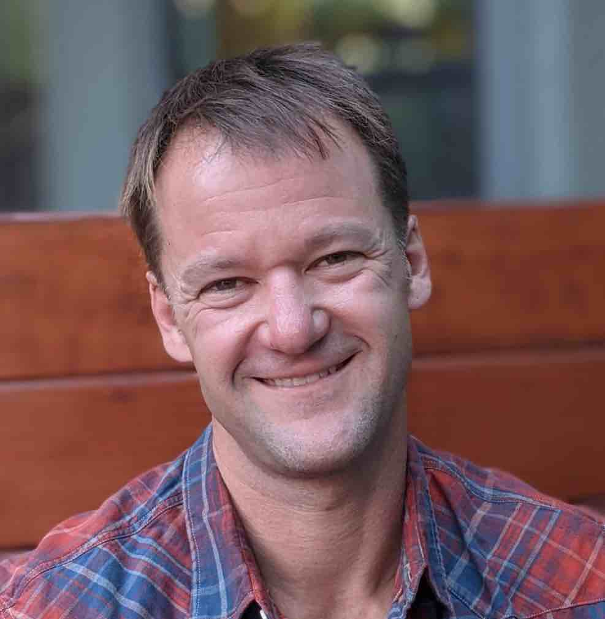

**Daniel Lassiter**Edinburgh

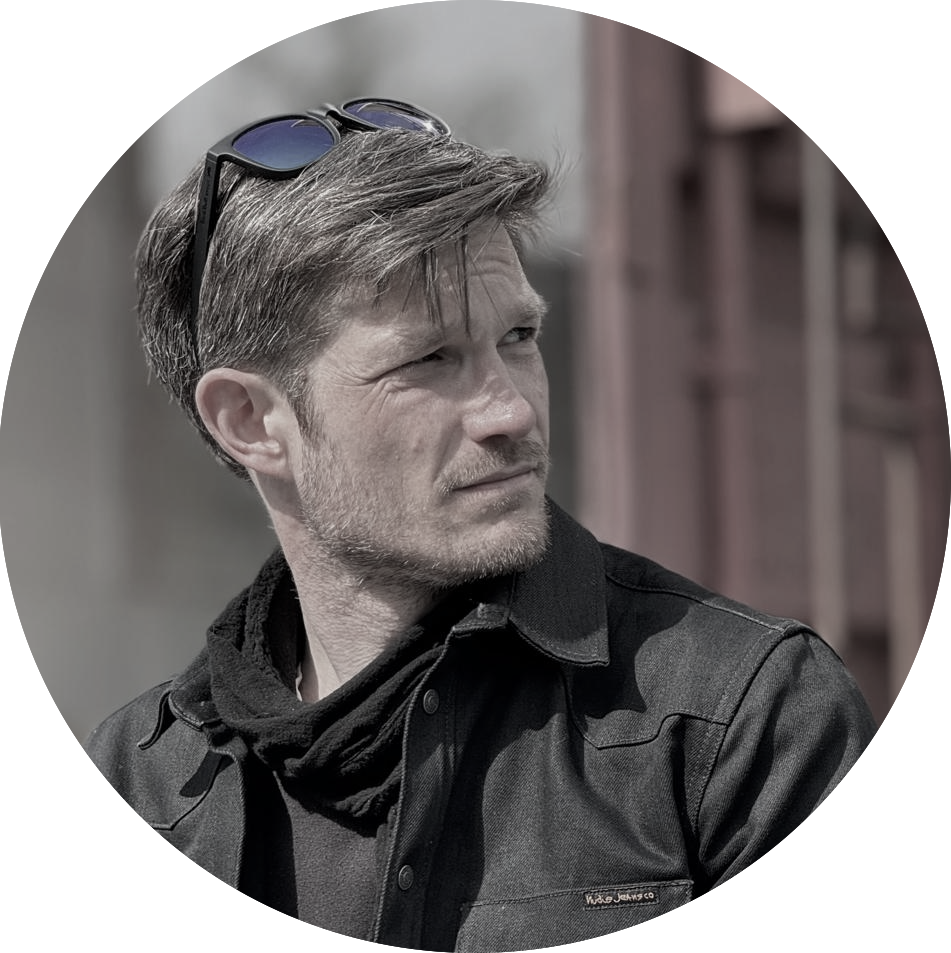

**Michael Franke**Tübingen

## Correlation is not causation. But...Reichenbach gives us a rationalization for causal inference

Stats 101  
correlation ≠ causation

↔

Reichenbach  
every non-accidental correlation is due to some causal structure

In communication, it can therefore be rational to infer a speaker’s causal belief from  
“A is associated with B” — even though causation is not part of the literal meaning.

1Reichenbach (1956)

## OverviewDoes this inference affect decisions, and does communicative context matter?

[figure not shown]

**Action**  
cultivate both plants?

→

**Language**  
recall or advise

→

**Belief**  
posterior − prior

2

## Experiment 1: Reproduction as message passingFree production after the same intervention choice · N = 99

[figure not shown]

Those who chose both plants used causal language more often.

The pattern appeared in recall and was clearest when participants advised another outpost.

Recall P = .98Advice P = .99

3

## Experiment 2: Pragmatic factors modulate belief updatingN = 404

### Directness

**Direct:** selected for you  
**Indirect:** found in an old note

### Speaker goal

**Cultivation:** improve yield  
**Localization:** find wild xeliherb

**Prior judgment**  
willingness to cultivate ralocrop

→

**Posterior judgment**  
willingness to cultivate ralocrop

correlational information

Primary dependent measure

posterior − prior

within-participant causal belief change

4

## Correlation increased causal commitment

[figure not shown]

89–91% became more willing to cultivate ralocrop.

Overall +.31 [.28, .34] Directness +.06 [.02, .09] Interaction +.07 · P = .97

Direct reports led to larger updates. The speaker-goal contrast appeared mainly when the report was addressed to the listener.

5

## Take-home

The same correlational statement produced different degrees of causal commitment across communicative contexts.

This pattern is difficult to explain as a context-insensitive bias. It supports a pragmatic account: listeners reason about why a particular speaker chose a correlational formulation in a particular setting.

Thank you

Poster Nr. 2586

6